# Bayesian linear models

- no evidence of non-normality
- no evidence of non-homogeneity of variance

**Example 3 (Poisson data)**

**Normality**

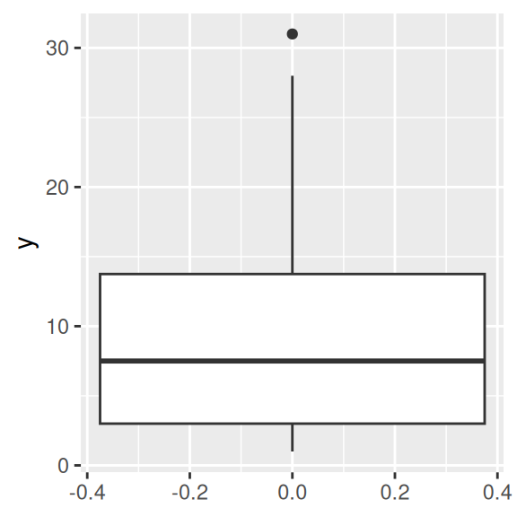

```r
dat3 |>
  ggplot(aes(y = y)) +
  geom_boxplot()
```

**Conclusions**

- there is strong evidence of non-normality
- each segment of the boxplot should get progressively larger

**Homogeneity of variance**

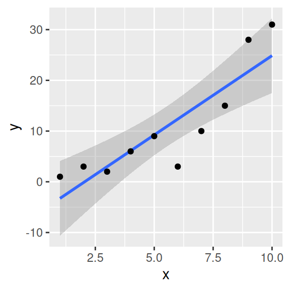

```r
dat3 |>
  ggplot(aes(y = y, x = x)) +
  geom_smooth(method = "lm") +
  geom_point()
```

**Conclusions**

- the spread of noise does not look random along the line of best fit.
- homogeneity of variance is difficult to assess in the presence of distributional issues (such as non-normality in this case) as they can result in non-linearity (apparent here)

**Linearity**

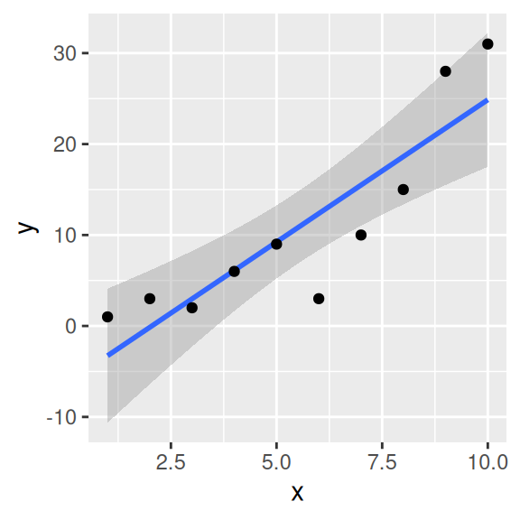

```r
dat3 |>
  ggplot(aes(y = y, x = x)) +
  geom_smooth(method = "lm") +
  geom_point()
```

**Conclusions**

- the data do not appear to be linear

**Conclusions**

- there are obvious violations of the linear regression model assumptions
- we should consider a different model that does not assume normality

**Example 4 (NB data)**

**Normality**

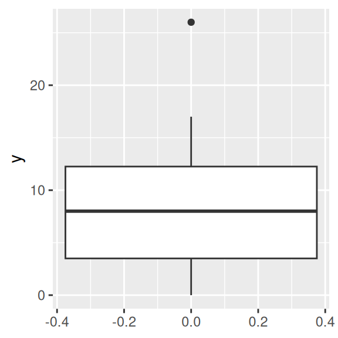

```r
dat4 |>
  ggplot(aes(y = y)) +
  geom_boxplot()
```

**Conclusions**

- there is strong evidence of non-normality
- each segment of the boxplot should get progressively larger

**Homogeneity of variance**

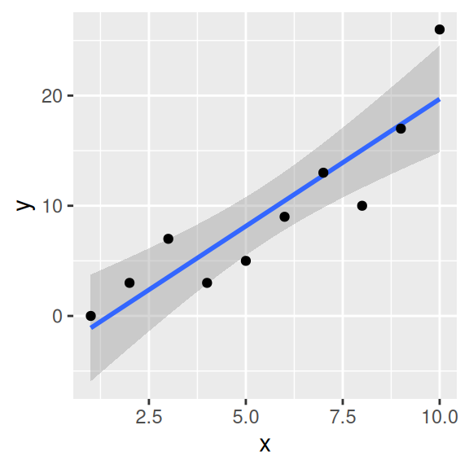

```r
dat4 |>
  ggplot(aes(y = y, x = x)) +
  geom_smooth(method = "lm") +
  geom_point()
```

**Conclusions**

- the spread of noise does not look random along the line of best fit.
- homogeneity of variance is difficult to assess in the presence of distributional issues (such as non-normality in this case) as they can result in non-linearity (apparent here)

**Linearity**

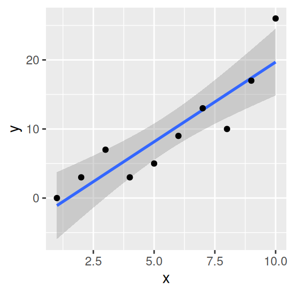

```r
dat4 |>
  ggplot(aes(y = y, x = x)) +
  geom_smooth(method = "lm") +
  geom_point()
```

**Conclusions**

- the data do not appear to be linear

**Conclusions**

- there are obvious violations of the linear regression model assumptions
- we should consider a different model that does not assume normality

**Example 5 (Binary data)**

**Normality**

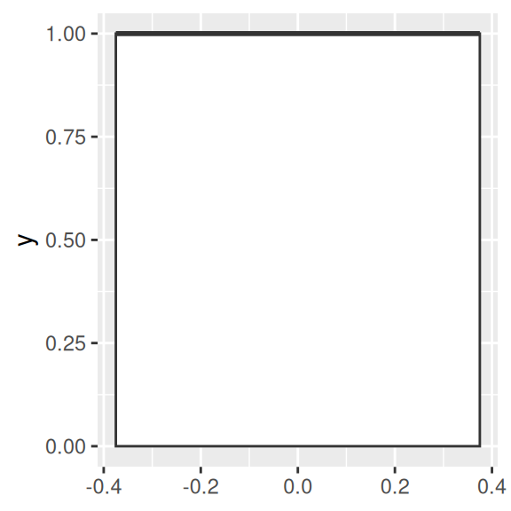

```r
dat5 |>
  ggplot(aes(y = y)) +
  geom_boxplot()
```

**Conclusions**

- clearly a set of 0’s and 1’s cant be normally distributied.

**Homogeneity of variance**

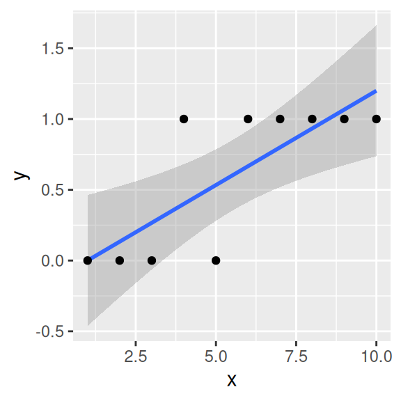

```r
dat5 |>
  ggplot(aes(y = y, x = x)) +
  geom_smooth(method = "lm") +
  geom_point()
```

**Conclusions**

- the spread of noise does not look random (or equal) along the line of best fit.

**Linearity**

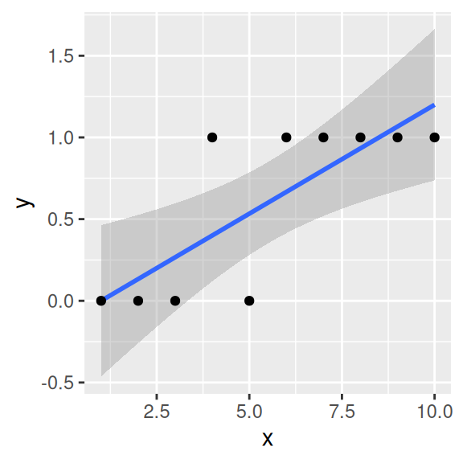

```r
dat5 |>
  ggplot(aes(y = y, x = x)) +
  geom_smooth(method = "lm") +
  geom_point()
```

**Conclusions**

- the data are clearly not linear

**Conclusions**

- there are obvious violations of the linear regression model assumptions
- we should consider a different model that does not assume normality

**Example 6 (Binomial data)**

**Normality**

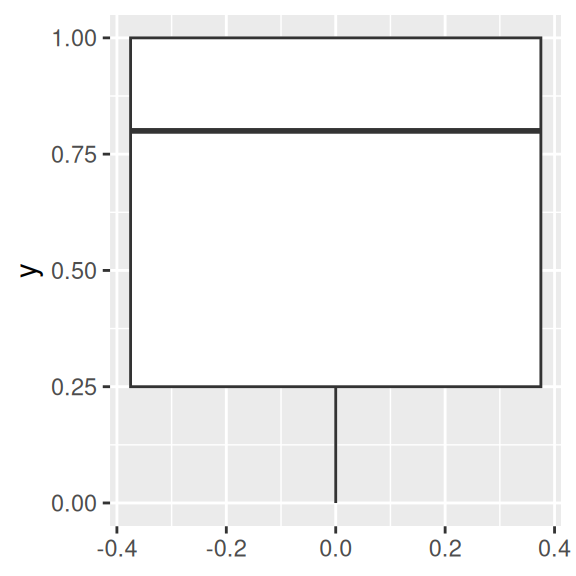

```r
dat6 |>
  ggplot(aes(y = y)) +
  geom_boxplot()
```

**Conclusions**

- distribution is not normal and is truncated

**Homogeneity of variance**

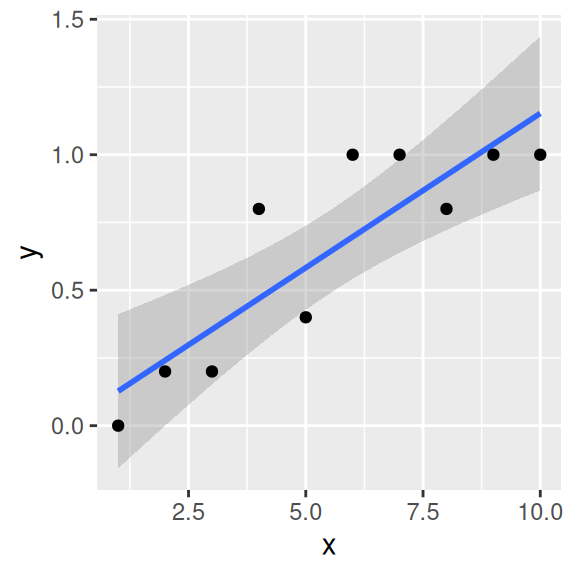

```r
dat6 |>
  ggplot(aes(y = y, x = x)) +
  geom_smooth(method = "lm") +
  geom_point()
```

**Conclusions**

- the spread of noise does not look random (or equal) along the line of best fit.

**Linearity**

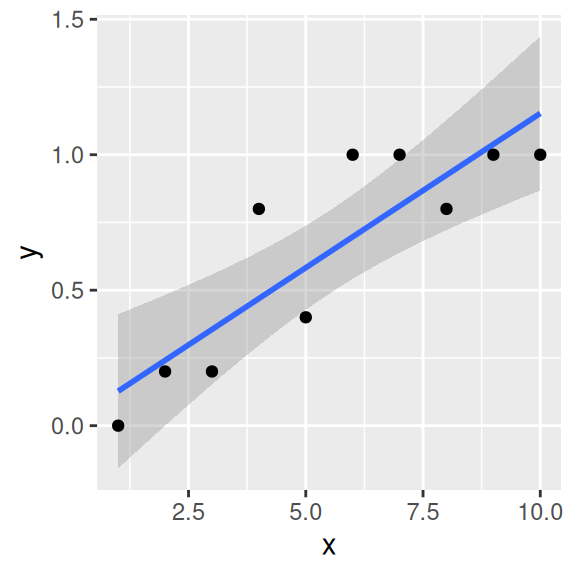

```r
dat6 |>
  ggplot(aes(y = y, x = x)) +
  geom_smooth(method = "lm") +
  geom_point()
```

**Conclusions**

- although there is no evidence of non-linearity from this small data set, it is worth noting that the line of best fit does extend outside the logical response range [0.1] within the range of observed $x$ values. That is, a simple linear model would predict proportions higher than 100% at high values of $x$

**Conclusions**

- there are obvious violations of the linear regression model assumptions
- we should consider a different model that does not assume normality

# 7 Fitting models

**Example 1 (Gaussian data)**

**Raw predictor**

**Define priors**

One way to assess the priors is to have the MCMC sampler sample purely from the prior predictive distribution without conditioning on the observed data. Doing so provides a glimpse at the range of predictions possible under the priors. On the one hand, wide ranging predictions would ensure that the priors are unlikely to influence the actual predictions once they are conditioned on the data. On the other hand, if they are too wide, the sampler is being permitted to traverse into regions of parameter space that are not logically possible in the context of the actual underlying ecological context. Not only could this mean that illogical parameter estimates are possible, when the sampler is traversing regions of parameter space that are not supported by the actual data, the sampler can become unstable and have difficulty.

In `brms`, we can inform the sampler to draw from the prior predictive distribution instead of conditioning on the response, by running the model with the `sample_prior = 'only'` argument. Unfortunately, this cannot be applied when there are flat priors (since the posteriors will necessarily extend to negative and positive infinity). Therefore, in order to use this useful routine, we need to make sure that we have defined a proper prior for all parameters.

Earlier we suggested the following priors might be useful:

- $\beta_0$: Normal prior centred at 31.21 with a variance of 15.17
  - mean:

    ```r
    dat$y |> median() |> round(2)
    ```

    ```
    [1] 31.21
    ```

  - variance:

    ```r
    dat$y |> mad() |> round(2)
    ```

    ```
    [1] 15.17
    ```

- $\beta_1$: *t* distribution (3 degrees of freedom) prior centred at 0 with a variance of 4.09
  - mean: since effects are differences and we may not want to pre-determine the direction (polarity) of any trends, it is typical to define effects priors with means of 0
  - variance:

    ```r
    mad(dat$y) / mad(dat$x) |> round(2)
    ```

    ```
    [1] 4.090138
    ```

- $\sigma$: (half) *t* distribution (3 degrees of freedom) centred at 0 with a variance of 15.17
  - variance:

    ```r
    dat$y |> mad() |> round(2)
    ```

    ```
    [1] 15.17
    ```

It might be use usefull to understand what some of these distributions look like. For example, we have used both a normal (Gaussian) distribution and a flatter *t* distribution for y-intercept and slope respectively. This was a somewhat arbitrary choice. We could easily have gone with either normal or *t* distributions for all of the above parameters. To visualise prior distributions for the slope based on both normal and *t* distributions:

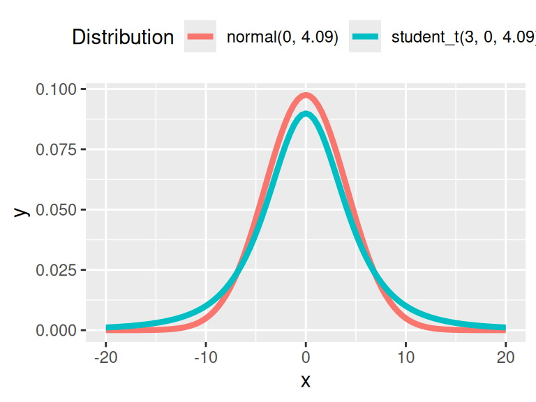

```r
standist::visualize("normal(0, 4.09)", "student_t(3, 0, 4.09)", xlim = c(-20, 20))
```

Evidently, the *t* distribution (with 3 degrees of freedom) is wider than the normal distribution. The former should be more robust to data with values that are less concentrated around the mean.

```r
priors <- prior(normal(31.21, 15.17), class = "Intercept") +
    prior(student_t(3, 0, 4.09), class = "b") +
    prior(student_t(3, 0, 15.17), class = "sigma")
```

**Fit the model**

$$\begin{align}
y_i \sim{}& N(\mu_i, \sigma^2)\\
\mu_i =& \beta_0 + \beta_1 x_i\\
\end{align}$$

1. start by fitting the model and sampling from the priors only

```r
dat1a.brm <- brm(bf(y ~ x),
                data=dat,
                prior=priors,
                sample_prior = 'only',
                iter = 5000,
                warmup = 1000,
                chains = 3, cores = 3,
                thin = 5,
                #backend = 'cmdstan',
                refresh = 0)
```

2. explore the range of posterior predictions resulting from the priors alone

```
Ignoring unknown labels:
• fill : "NA"
• colour : "NA"
Ignoring unknown labels:
• fill : "NA"
• colour : "NA"
```

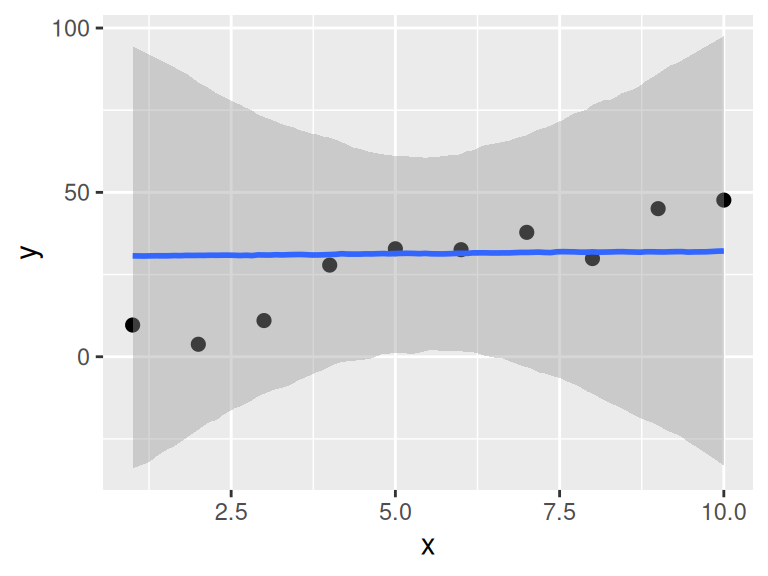

```r
dat1a.brm |>
    conditional_effects() |>
    plot(points = TRUE)
```

**Conclusions:**

- the grey ribbon above represents the credible range of the posterior predictions
- this ribbon is substantially wider than the observed data (black points), suggesting that the priors are not overly narrow
- the range of posterior predictions are not widely unreasonable (although we could argue that negative predictions might be illogical) since the maximums are not multiple orders of magnitude above the observed data.
3. now refit the model such that it samples from both the priors and likelihood (that is allow the data to have an impact on the estimates)

```r
dat1a.brm2 <- update(dat1a.brm,
    sample_prior = "yes"
)
```

```
The desired updates require recompiling the model
```

4. re-explore the range of posterior predictions resulting from the fitted model

```
Ignoring unknown labels:
• fill : "NA"
• colour : "NA"
Ignoring unknown labels:
• fill : "NA"
• colour : "NA"
```

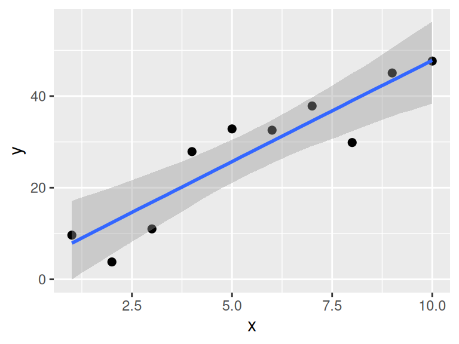

```r
dat1a.brm2 |>
    conditional_effects() |>
    plot(points = TRUE)
```

**Conclusions:**

- the range of the posteriors are now substantially reduced (now that the model includes both data and priors)
- this suggests that the patterns are being driven predominantly by the data
5. compare the priors and posteriors to further confirm that the priors are not overly influential

When we have indicated that the posterior should be informed by both the prior and the posterior, both prior (governed by priors alone) and posterior (governed by both priors and data/likelihood) draws are returned. These can be compared by exploring the probabilities associated with specific hypotheses - the most obvious of which is that of no effect (that the parameter = 0).

When doing so, ideally the posterior should be distinct from the prior. By distinct, I mean that the posteriors should be clearly distinguishable from the priors. Ideally, the priors should be less variable than the priors. If this is not the case, it might suggest that the posteriors are being too strongly driven by the priors.

```r
dat1a.brm2 |> tidybayes::get_variables()
```

```
 [1] "b_Intercept"     "b_x"             "sigma"           "Intercept"
 [5] "prior_Intercept" "prior_b"         "prior_sigma"     "lprior"
 [9] "lp__"            "accept_stat__"   "stepsize__"      "treedepth__"
[13] "n_leapfrog__"    "divergent__"     "energy__"
```

```r
dat1a.brm2 |> hypothesis("x = 0") |> plot()
```

[output not shown]

```r
dat1a.brm2 |> hypothesis("sigma = 0", class = "") |> plot()
```

[output not shown]

Unfortunately, it is not possible to do this comparison sensibly for the intercept. The reason for this is that the prior for intercept was applied to an intercept that is associated with centred continuous predictors (predictors are centred behind the scenes). Since we did not centre the predictor, the intercept returned is as if uncentred. Hence, the prior and posterior are on different scales.

```r
dat1a.brm2 |> tidybayes::get_variables()
```

```
 [1] "b_Intercept"     "b_x"             "sigma"           "Intercept"
 [5] "prior_Intercept" "prior_b"         "prior_sigma"     "lprior"
 [9] "lp__"            "accept_stat__"   "stepsize__"      "treedepth__"
[13] "n_leapfrog__"    "divergent__"     "energy__"
```

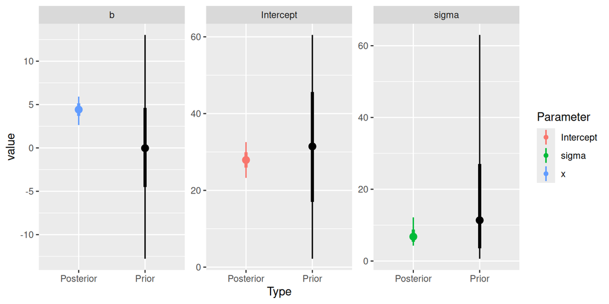

```r
dat1a.brm2 |> SUYR_prior_and_posterior()
```

**Conclusions:**

- each of the priors are substantially wider than the posteriors
- the posteriors are definitely distinct from their respective priors and thus we can conclude that the priors and not driving the posteriors (e.g. they are not influencing the outcomes)
- the priors are simply regularising the parameters such that they are only sampled from plausible regions

**Centered predictor**

**Define priors**

Unless you explicitly direct `brm` to include a user-defined intercept, the priors on the default intercept should assume that the predictor(s) are centered (because `brm` will automatically center all continuous predictors).

Lets try the following priors:

- $\beta_0$: Normal prior centred at 31.21 with a variance of 15.17
  - mean:

    ```r
    dat$y |> median() |> round(2)
    ```

    ```
    [1] 31.21
    ```

  - variance:

    ```r
    dat$y |> mad() |> round(2)
    ```

    ```
    [1] 15.17
    ```

- $\beta_1$: *t* distribution (3 degrees of freedom) prior centered at 0 with a variance of 4.09
  - mean: since effects are differences and we may not want to pre-determine the direction (polarity) of any trends, it is typical to define effects priors with means of 0
  - variance:

    ```r
    mad(dat$y) / mad(dat$x) |> round(2)
    ```

    ```
    [1] 4.090138
    ```

- $\sigma$: (half) *t* distribution (3 degrees of freedom) centred at 0 with a variance of 15.17
  - variance:

    ```r
    dat$y |> mad() |> round(2)
    ```

    ```
    [1] 15.17
    ```

```r
priors <- prior(normal(31.21, 15.17), class = "Intercept") +
    prior(student_t(3, 0, 4.09), class = "b") +
    prior(student_t(3, 0, 15.17), class = "sigma")
```

**Fit the model**

$$\begin{align}
y_i \sim{}& N(\mu_i, \sigma^2)\\
\mu_i =& \beta_0 + \beta_1 (x_i - \bar{x})\\
\end{align}$$

1. start by fitting the model and sampling from the priors only

```r
dat1b.brm <- brm(bf(y ~ scale(x, scale = FALSE)),
                data=dat,
                prior=priors,
                sample_prior = 'only',
                iter = 5000,
                warmup = 1000,
                chains = 3, cores = 3,
                thin = 5,
                #backend = 'cmdstan',
                refresh = 0)
```

2. explore the range of posterior predictions resulting from the priors alone

```
Ignoring unknown labels:
• fill : "NA"
• colour : "NA"
Ignoring unknown labels:
• fill : "NA"
• colour : "NA"
```

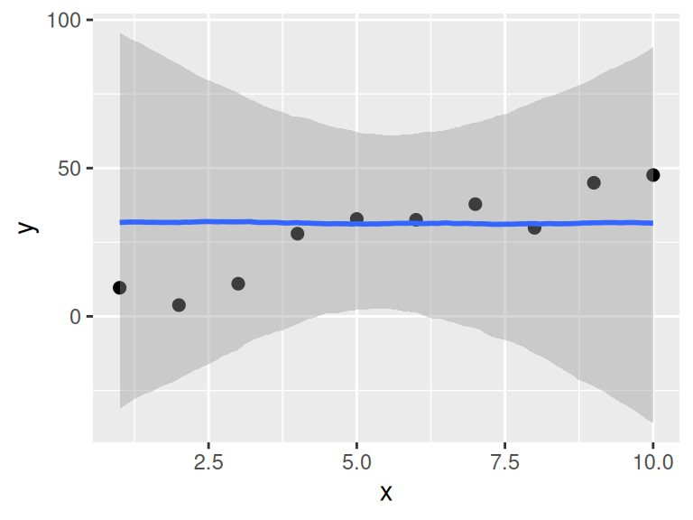

```r
dat1b.brm |>
    conditional_effects() |>
    plot(points = TRUE)
```

**Conclusions:**

- the grey ribbon above represents the credible range of the posterior predictions
- this ribbon is substantially wider than the observed data (black points), suggesting that the priors are not overly narrow
- the range of posterior predictions are not widely unreasonable (although we could argue that negative predictions might be illogical) since the maximums are not multiple orders of magnitude above the observed data.
3. now refit the model such that it samples from both the priors and likelihood (that is allow the data to have an impact on the estimates)

```r
dat1b.brm2 <- update(dat1b.brm,
    sample_prior = "yes"
)
```

```
The desired updates require recompiling the model
```

4. re-explore the range of posterior predictions resulting from the fitted model

```
Ignoring unknown labels:
• fill : "NA"
• colour : "NA"
Ignoring unknown labels:
• fill : "NA"
• colour : "NA"
```

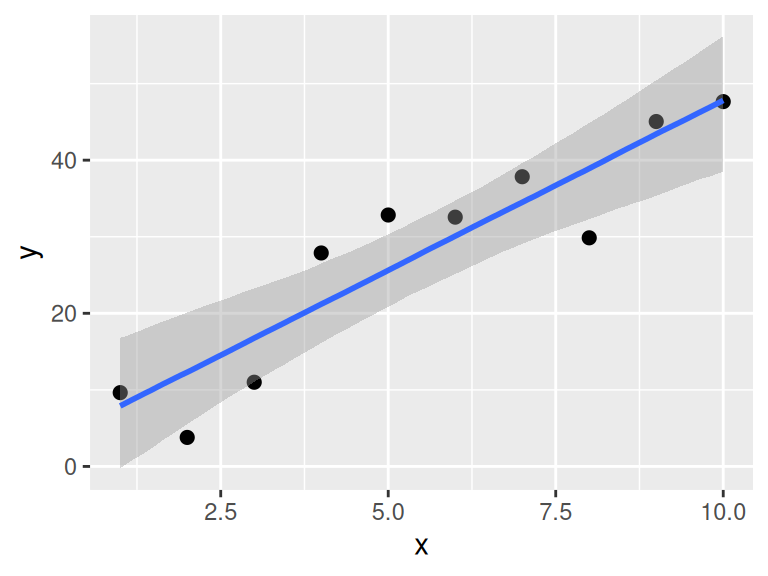

```r
dat1b.brm2 |>
    conditional_effects() |>
    plot(points = TRUE)
```

**Conclusions:**

- the range of the posteriors are now substantially reduced (now that the model includes both data and priors)
- this suggests that the patterns are being driven predominantly by the data
5. compare the priors and posteriors to further confirm that the priors are not overly influential

When we have indicated that the posterior should be informed by both the prior and the posterior, both prior (governed by priors alone) and posterior (governed by both priors and data/likelihood) draws are returned. These can be compared by exploring the probabilities associated with specific hypotheses - the most obvious of which is that of no effect (that the parameter = 0).

When doing so, ideally the posterior should be distinct from the prior. By distinct, I mean that the posteriors should be clearly distinguishable from the priors. Ideally, the priors should be less variable than the priors. If this is not the case, it might suggest that the posteriors are being too strongly driven by the priors.

```r
dat1b.brm2 |> tidybayes::get_variables()
```

```
 [1] "b_Intercept"          "b_scalexscaleEQFALSE" "sigma"
 [4] "Intercept"            "prior_Intercept"      "prior_b"
 [7] "prior_sigma"          "lprior"               "lp__"
[10] "accept_stat__"        "stepsize__"           "treedepth__"
[13] "n_leapfrog__"         "divergent__"          "energy__"
```

```r
dat1b.brm2 |> hypothesis("scalexscaleEQFALSE = 0") |> plot()
```

[output not shown]

```r
dat1b.brm2 |> hypothesis("sigma = 0", class = "") |> plot()
```

[output not shown]

```r
dat1b.brm2 |> tidybayes::get_variables()
```

```
 [1] "b_Intercept"          "b_scalexscaleEQFALSE" "sigma"
 [4] "Intercept"            "prior_Intercept"      "prior_b"
 [7] "prior_sigma"          "lprior"               "lp__"
[10] "accept_stat__"        "stepsize__"           "treedepth__"
[13] "n_leapfrog__"         "divergent__"          "energy__"
```

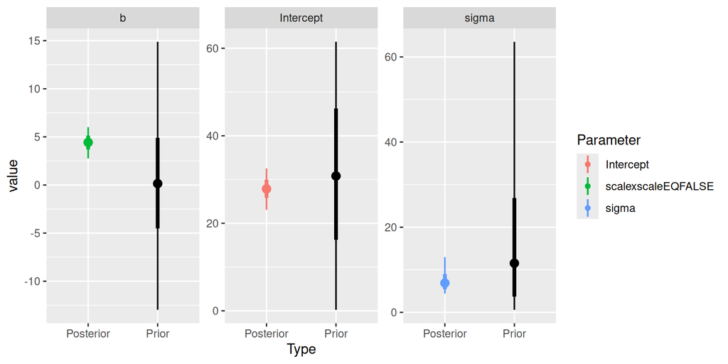

```r
dat1b.brm2 |> SUYR_prior_and_posterior()
```

**Conclusions:**

- each of the priors are substantially wider than the posteriors
- the posteriors are definitely distinct from their respective priors and thus we can conclude that the priors and not driving the posteriors (e.g. they are not influencing the outcomes)
- the priors are simply regularising the parameters such that they are only sampled from plausible regions

**Standardised predictor**

**Define priors**

When the predictor is standardised, it simplifies prior definition because we no longer need to consider the scale of the predictor.

Lets try the following priors:

- $\beta_0$: Normal prior centred at 31.21 with a variance of 15.17
  - mean:

    ```r
    dat$y |> median() |> round(2)
    ```

    ```
    [1] 31.21
    ```

  - variance:

    ```r
    dat$y |> mad() |> round(2)
    ```

    ```
    [1] 15.17
    ```

- $\beta_1$: *t* distribution (3 degrees of freedom) prior centered at 0 with a variance of 15.17
  - mean: since effects are differences and we may not want to pre-determine the direction (polarity) of any trends, it is typical to define effects priors with means of 0
  - variance:

    ```r
    mad(dat$y) |> round(2)
    ```

    ```
    [1] 15.17
    ```

- $\sigma$: (half) *t* distribution (3 degrees of freedom) centred at 0 with a variance of 15.17
  - variance:

    ```r
    dat$y |> mad() |> round(2)
    ```

    ```
    [1] 15.17
    ```

```r
priors <- prior(normal(31.21, 15.17), class = "Intercept") +
    prior(student_t(3, 0, 15.17), class = "b") +
    prior(student_t(3, 0, 15.17), class = "sigma")
```

**Fit the model**

$$\begin{align}
y_i \sim{}& N(\mu_i, \sigma^2)\\
\mu_i =& \beta_0 + \beta_1 (x_i - \bar{x})/\sigma_{x}\\
\end{align}$$

1. start by fitting the model and sampling from the priors only

```r
dat1c.brm <- brm(bf(y ~ scale(x)),
                data=dat,
                prior=priors,
                sample_prior = 'only',
                iter = 5000,
                warmup = 1000,
                chains = 3, cores = 3,
                thin = 5,
                #backend = 'cmdstan',
                refresh = 0)
```

2. explore the range of posterior predictions resulting from the priors alone

```
Ignoring unknown labels:
• fill : "NA"
• colour : "NA"
Ignoring unknown labels:
• fill : "NA"
• colour : "NA"
```

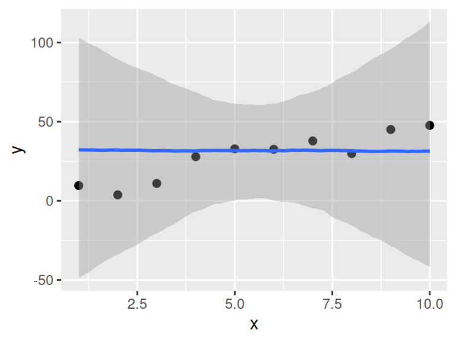

```r
dat1c.brm |>
    conditional_effects() |>
    plot(points = TRUE)
```

**Conclusions:**

- the grey ribbon above represents the credible range of the posterior predictions
- this ribbon is substantially wider than the observed data (black points), suggesting that the priors are not overly narrow
- the range of posterior predictions are not widely unreasonable (although we could argue that negative predictions might be illogical) since the maximums are not multiple orders of magnitude above the observed data.
3. now refit the model such that it samples from both the priors and likelihood (that is allow the data to have an impact on the estimates)

```r
dat1c.brm2 <- update(dat1c.brm,
    sample_prior = "yes"
)
```

```
The desired updates require recompiling the model
```

4. re-explore the range of posterior predictions resulting from the fitted model

```
Ignoring unknown labels:
• fill : "NA"
• colour : "NA"
Ignoring unknown labels:
• fill : "NA"
• colour : "NA"
```

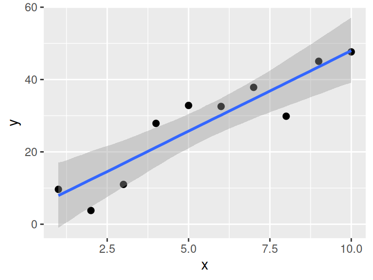

```r
dat1c.brm2 |>
    conditional_effects() |>
    plot(points = TRUE)
```

**Conclusions:**

- the range of the posteriors are now substantially reduced (now that the model includes both data and priors)
- this suggests that the patterns are being driven predominantly by the data
5. compare the priors and posteriors to further confirm that the priors are not overly influential

When we have indicated that the posterior should be informed by both the prior and the posterior, both prior (governed by priors alone) and posterior (governed by both priors and data/likelihood) draws are returned. These can be compared by exploring the probabilities associated with specific hypotheses - the most obvious of which is that of no effect (that the parameter = 0).